# Assignment 4

## Submit as an HTML file

Print your name and Emory ID below

```python
name="Will_Tu"
Emory_ID="2433616"
print(name)
print(Emory_ID)
```

```
Will_Tu
2433616
```

Importing relevant libraries (matplotlib, NumPy)

```python
import matplotlib.pyplot as plt
import numpy as np
import pandas as pd
```

### a) For-loops and Conditional Statements

Using the list of test scores below, create a new list of students who made the honor roll (students with a grade greater than or equal to 90).

- Create a second list containing student names, where each name directly corresponds to a score in `test_scores`.
- Use a for loop to iterate through both lists and store the names and scores of students who made the honor roll in two new lists:
  - `honor_roll_names`: The names of students who made the honor roll.
  - `honor_roll_scores`: The scores of students who made the honor roll.
- Print the results of both lists.

```python
test_scores = [85, 92, 88, 96, 75, 91, 89, 98, 72, 90]
student_names = ["Alice", "Bob", "Charlie", "David", "Eve",
                 "Frank", "Grace", "Hannah", "Ivy", "Jack","Will"]
```

```python
honor_roll_names = []
honor_roll_scores = []

 #Method1: use the zip function, which pairs two items
for name, score in zip(student_names, test_scores):
    if score >= 90:
        honor_roll_scores.append(score)
        honor_roll_names.append(name)

print(honor_roll_names)
print(honor_roll_scores)
```

```
['Bob', 'David', 'Frank', 'Hannah', 'Jack']
[92, 96, 91, 98, 90]
```

```python
# Write your answer here

test_scores = [85, 92, 88, 96, 75, 91, 89, 98, 72, 90]
student_names = ["Alice", "Bob", "Charlie", "David", "Eve",
                 "Frank", "Grace", "Hannah", "Ivy", "Jack",]

# This list will store only those (student, score) pairs where score >= 90
honor_roll_names = []
honor_roll_scores=[]
for i in range(len(test_scores)):
    if test_scores[i] >= 90:
        honor_roll_names.append(student_names[i])
        honor_roll_scores.append(test_scores[i])
print(honor_roll_names)
print(honor_roll_scores)
```

```
['Bob', 'David', 'Frank', 'Hannah', 'Jack']
[92, 96, 91, 98, 90]
```

### b) Follow-up to Part (a)

Using NumPy, perform the following operations on the `honor_roll_scores` list:

- Count and print the total number of students who made the honor roll using `np.size()`.
- Calculate and print the average score of the students on the honor roll using `np.mean()`.
- Determine and print the highest score from the honor roll using `np.max()`.
- Print the total number of students, average score and the highest score found.

#### Hint:

First convert the scores array to a NumPy array.  
Use the following NumPy functions where necessary:

- [`np.size()`](https://numpy.org/doc/stable/reference/generated/numpy.size.html)
- [`np.mean()`](https://numpy.org/doc/stable/reference/generated/numpy.mean.html)
- [`np.max()`](https://numpy.org/doc/stable/reference/generated/numpy.amax.html)

```python
#Write your answer here
import numpy as np
np_honor_roll_scores=np.array(honor_roll_scores)
print(np.size(np_honor_roll_scores))
print(np.mean(np_honor_roll_scores))
print(np.max(np_honor_roll_scores))
# A summary that meets requirement 4
print("There are",np.size(np_honor_roll_scores),"students on the honor list.","The average score of the students on the honor roll is",np.mean(np_honor_roll_scores),"The highest score from the honor roll is",np.max(np_honor_roll_scores))
```

```
5
93.4
98
There are 5 students on the honor list. The average score of the students on the honor roll is 93.4 The highest score from the honor roll is 98
```

c) For-loops + plotting

- Create an array of x-values with all the integers between 1 and 15.
- Create a vector `vec_y1` where each element is computed from the formula  
  $ y_1 = 3x^3 + 5x^2 - x$.
- Create a vector `vec_y2` where each element is computed from the formula  
  $ y_2 = x^4 - 6x^2 + 2x$.
- Create an object `list_vectors` with elements `vec_y1` and `vec_y2`.
- Create a for-loop that goes through each element of `list_vectors` and plots each list of $y$ values against $x$.

Note: The final output should be a 2-dimensional scatter plot with two sets of points, with the $y_1$ and $y_2$ on the vertical axis, and the $x$ values  
on the horizontal axis. Remember to always label the axes and add a title to the plot to make it look more professional.

```
[ 1  2  3  4  5  6  7  8  9 10 11 12 13 14 15]
[    7    42   123   268   495   822  1267  1848  2583  3490  4587  5892
  7423  9198 11235]
[    1   -14   -41   -88  -131  -194  -277  -356  -455  -566  -689  -848
  -987 -1146 -1325]
[array([    7,    42,   123,   268,   495,   822,  1267,  1848,  2583,
        3490,  4587,  5892,  7423,  9198, 11235]), array([    1,   -14,   -41,   -88,  -131,  -194,  -277,  -356,  -455,
        -566,  -689,  -848,  -987, -1146, -1325])]
```

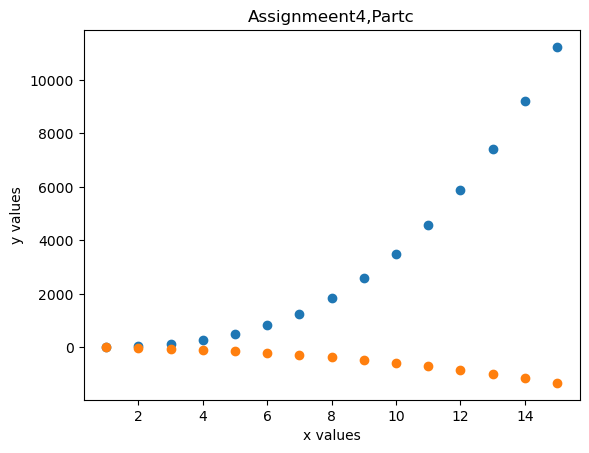

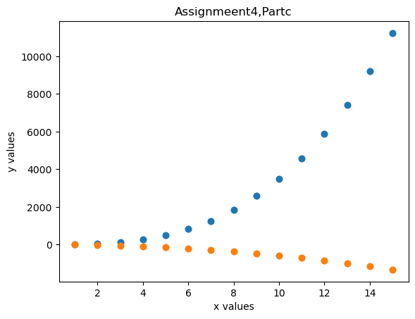

```python
#Write your answer here
# ctrl and plus sign: zoom in

vec_x=np.array(range(1,16))
print(vec_x)

def my_function(x):
    y_1=3*x**3+5*x**2-x
    return y_1

vec_y1=my_function(vec_x)
print(vec_y1)

def my_preciousy2(x):
    y_2=x^4-6*x**2+2*x
    return y_2
vec_y2=my_preciousy2(vec_x)
print(vec_y2)

list_vectors=[vec_y1,vec_y2]
print(list_vectors)

x=[]
y_1=[]
y_2=[]

for i in range(len(list_vectors)):
    x.append(vec_x)
    y_1.append(vec_y1)
    y_2.append(vec_y2)


    plt.scatter(x,y_1)
    plt.scatter(x,y_2)
    plt.title("Assignmeent4,Partc")
    plt.ylabel("y values")
    plt.xlabel("x values")

    plt.show()
```

### d) Average grades, learn how to use zip()

- Below, write a chunk of code that prints out the average grade for each student. The names and grades are given in the lists below.
- The program should print the student's name and their average grade, formatted like this:

[output not shown]

Hints/Tips:

- You can use zip() to iterate through multiple lists at once, making the code cleaner.
- You can learn more about zip() here: [Python zip() Function](https://www.geeksforgeeks.org/zip-in-python/)
- When you print the statements out, you can cast the average grade to a string using str()
- Ignore the rounding, the number of decimal places in each calculated average grade does not matter.

```python
student_names = ["Alice", "Bob", "Charlie", "David", "Eve"]
grades1 = [85, 92, 88, 96, 75]
grades2 = [90, 80, 89, 94, 82]
grades3 = [88, 95, 91, 98, 78]
```

```python
# Write your answer here
for individual_name, g1, g2, g3 in zip(student_names, grades1, grades2, grades3):
    average_grade = (g1 + g2 + g3) / 3
    print(individual_name,"'s", "average grade:", average_grade)
```

```
Alice 's average grade: 87.66666666666667
Bob 's average grade: 89.0
Charlie 's average grade: 89.33333333333333
David 's average grade: 96.0
Eve 's average grade: 78.33333333333333
```

### e) Simulating and visualizing

In order to recieve full credit, please answer the first question in the markdown cell below the code. Answer the second question by making your changes to the code chunk below.

- How does the sample size and the number of simulations affect the distribution of the sample means in the code below?
- Generate and plot multiple histograms with different sample sizes:
  - Create at three histograms: one with a small sample size (e.g., 10), one with a medium sample size (e.g., 100), and one with a large sample size (e.g., 1000).
  - Make sure that the number of simulations is the same for all three (set the number of simulations to 250)

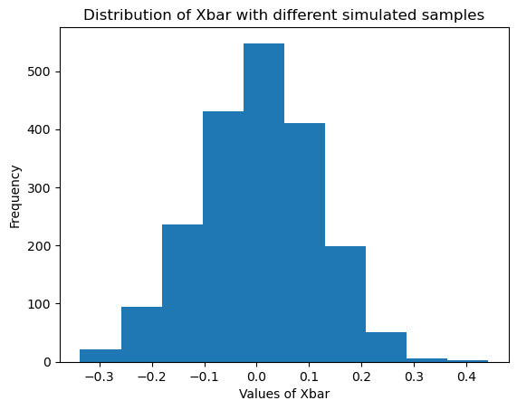

```python
num_simulations = 2000
sample_size     = 100


vec_xbar = [None] * num_simulations

for iteration in range(num_simulations):
    vec_unif  = np.random.uniform(low = -2, high=2, size = sample_size)
    vec_xbar[iteration] = vec_unif.mean()

vec_xbar

plt.hist(vec_xbar)
plt.title("Distribution of Xbar with different simulated samples")
plt.ylabel("Frequency")
plt.xlabel("Values of Xbar")
plt.show()
```

To answer the 1st question:

The number of simulations is correlated with the graph's "discreteness." If I run the graph with a very low number (such as 5) then the graph will look very discrete. It is not continuous, because there is a visible gap in between.

However, if I increase the number of simulations, the graph seems continuous. (discrete distribution versus continuous distribution)

On the other hand, if we fix the number of simulations while changing the number of sample sizes, the range decreases. The comparisons below show this difference: when sample size is merely 10, you have the range approximately 2, but when sample size is increased to 1000, the range is only about 0.2. Also, in probability, when you increase sample sizes, the distribution is becomes more similar to a normal distribution.

Below are my answers to the 2nd question within Q5

### Write your answer in this cell

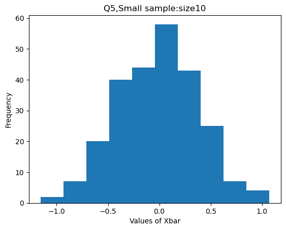

```python
#Small sample (write your answer here)

num_simulations = 250
sample_size     = 10


vec_xbar = [None] * num_simulations

for iteration in range(num_simulations):
    vec_unif  = np.random.uniform(low = -2, high=2, size = sample_size)
    vec_xbar[iteration] = vec_unif.mean()

vec_xbar

plt.hist(vec_xbar)
plt.title("Q5,Small sample:size10")
plt.ylabel("Frequency")
plt.xlabel("Values of Xbar")
plt.show()
```

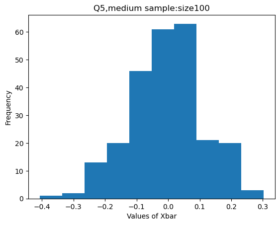

```python
#Medium sample (write your answer here)
num_simulations = 250
sample_size     = 100


vec_xbar = [None] * num_simulations

for iteration in range(num_simulations):
    vec_unif  = np.random.uniform(low = -2, high=2, size = sample_size)
    vec_xbar[iteration] = vec_unif.mean()

vec_xbar

plt.hist(vec_xbar)
plt.title("Q5,medium sample:size100")
plt.ylabel("Frequency")
plt.xlabel("Values of Xbar")
plt.show()
```

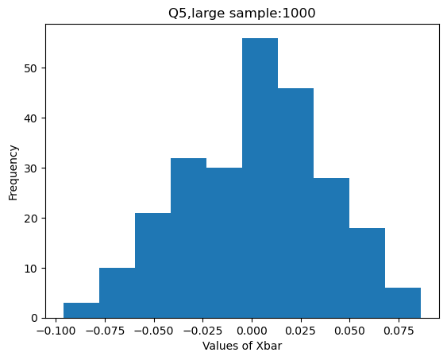

```python
#Large sample (write your answer here)
#Medium sample (write your answer here)
num_simulations = 250
sample_size     = 1000


vec_xbar = [None] * num_simulations

for iteration in range(num_simulations):
    vec_unif  = np.random.uniform(low = -2, high=2, size = sample_size)
    vec_xbar[iteration] = vec_unif.mean()

vec_xbar

plt.hist(vec_xbar)
plt.title("Q5,large sample:1000")
plt.ylabel("Frequency")
plt.xlabel("Values of Xbar")
plt.show()
```